# Public Health Scotland Group Project

```r
library(tidyverse)
library(janitor)
library(here)
library(leaflet)
library(sf)
library(infer)
here::here()
```

```
[1] "C:/Users/colin/Documents/rshiny_dashboard_project"
```

# Read in hospital location data;

```r
hospitals <- read_csv(here("raw_data/nhs_hospital_locations.csv")) %>% clean_names()
```

## Plotting (work in progress!)

```r
# hospitals %>%
#    st_transform('+proj=longlat +datum=WGS84') %>%  # reference coord structure from espg.io
#
#
#    hospitals %>%
#   st_crs(x_coordinate)





hospitals %>%
  leaflet() %>%
  addTiles() %>%
  addCircleMarkers(lng = -5.1155000,     # attempt to convert from degrees to lat/long
                   lat = 55.5430000,     # conversion was poor - had to adjust manually
                   radius = 5)
```

[interactive chart not shown]

## Occupied beds by area;

```r
beds_by_health_board <-
  read_csv(here("raw_data/beds_by_nhs_board_of_treatment_and_specialty.csv")) %>%
  clean_names()
```

Remove unwanted info from hospital locations in preparation for joining;

```r
hospitals_trim <- hospitals %>%
  select(location, location_name)
```

Join decoded hospital locations to beds by health board data;

```r
joined_beds_hb <- left_join(beds_by_health_board, hospitals_trim, by = "location")

# then remove duplicate rows
joined_beds_hb_trim <-  joined_beds_hb %>%
  filter(location != hb )
```

```r
# Remove "qualifier" columns full of NAs
joined_beds_hb <- joined_beds_hb %>%
  select(!ends_with("qf"))

# check NA count across all columns
joined_beds_hb %>%
  summarise(across(.cols =everything(), ~ sum(is.na(.))))
```

| quarter | hb | location | specialty | specialty_name | all_staffed_beds | total_occupied_beds | average_available_staffed_beds | average_occupied_beds | percentage_occupancy | location_name |
| --- | --- | --- | --- | --- | --- | --- | --- | --- | --- | --- |
| 0 | 0 | 0 | 9927 | 0 | 0 | 0 | 0 | 0 | 11 | 12641 |

Still lots of NAs in “Specialty” (almost 30% of all rows), but will leave them for now.

## Plot total Percentage Hospital Bed Occupancy (Acute)

```r
# create a column with the average of the total % occupancy
total_avg_acute_occupancy <- joined_beds_hb %>%
  select(quarter, location_name, specialty_name, percentage_occupancy) %>%
  filter(specialty_name == "All Acute") %>%
  group_by(quarter) %>%
  summarise(mean_total_acute_occupancy = mean(percentage_occupancy, na.rm = TRUE))
# is 'mean' the correct measure here?
```

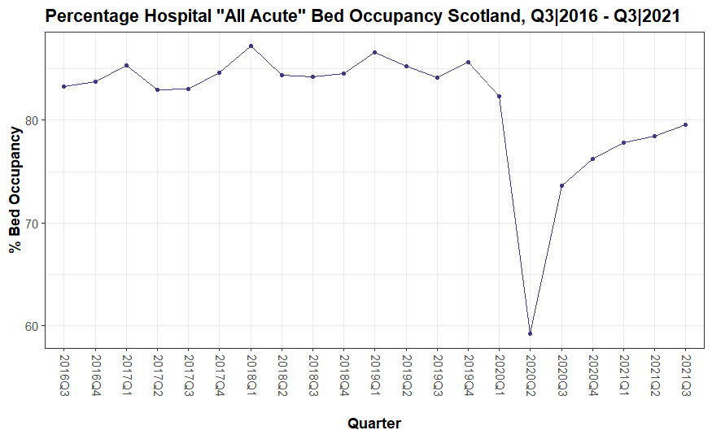

```r
total_avg_acute_occupancy %>%
  ggplot() +
  aes(x = quarter, y = mean_total_acute_occupancy) +
  geom_line(colour = "#433685", group = 1) +
  geom_point(colour = "#433685", size = 1) +
  theme_bw() +
  labs(title = "Percentage Hospital \"All Acute\" Bed Occupancy Scotland, Q3|2016 - Q3|2021",
       x = "\nQuarter",
       y = "% Bed Occupancy") +
  theme(axis.text.x = element_text(angle = 270, vjust = 0.25),
        title = element_text(face = "bold"))
```

## Plot% occupancy by health board;

```r
beds_by_hb_trim <- joined_beds_hb %>%
  select(quarter, hb, location_name, specialty_name, percentage_occupancy) %>%
  group_by(quarter, hb) %>%
  summarise(hb_mean_occupancy = mean(percentage_occupancy, na.rm = TRUE))
#Check NAs

# beds_by_hb_trim %>%
#   summarise(across(.cols =everything(), ~ sum(is.na(.))))
```

Health board codes are not easy to understand…

## Join health board code definitions;

```r
hb_codes <- read_csv(here("raw_data/phs_health_board_codes.csv")) %>% clean_names()
```

```r
beds_by_hb_trim<- left_join(beds_by_hb_trim, hb_codes)
# and tidy up...

beds_by_hb_trim <- beds_by_hb_trim %>%
  select(quarter, hb, hb_mean_occupancy, hb_name) %>%
  #remove country codes from regional data;
  filter(hb != "S92000003" & hb != "SB0801") %>%
  ungroup()
```

## Write cleaned ‘Bed Occupancy by Health Board’ data;

```r
write_csv(beds_by_hb_trim, "../clean_data/bed_occupancy_by_health_board_clean.csv")
```

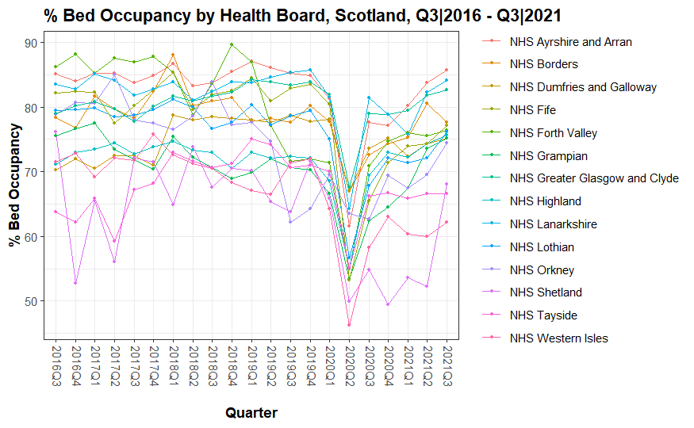

```r
beds_by_hb_trim %>%
  ggplot() +
  aes(x = quarter, y = hb_mean_occupancy, colour = hb_name, group = hb) +
  geom_line() +
  geom_point(size = 0.75) +
  theme_bw() +
  labs(title = "% Bed Occupancy by Health Board, Scotland, Q3|2016 - Q3|2021",
       x = "\nQuarter",
       y = "% Bed Occupancy") +
  theme(axis.text.x = element_text(angle = 270, vjust = 0.25),
        title = element_text(face = "bold"),
        legend.title = element_blank())
```

Is there an overall seasonal pattern to bed occupancy in all the data Q32016 - Q32021?

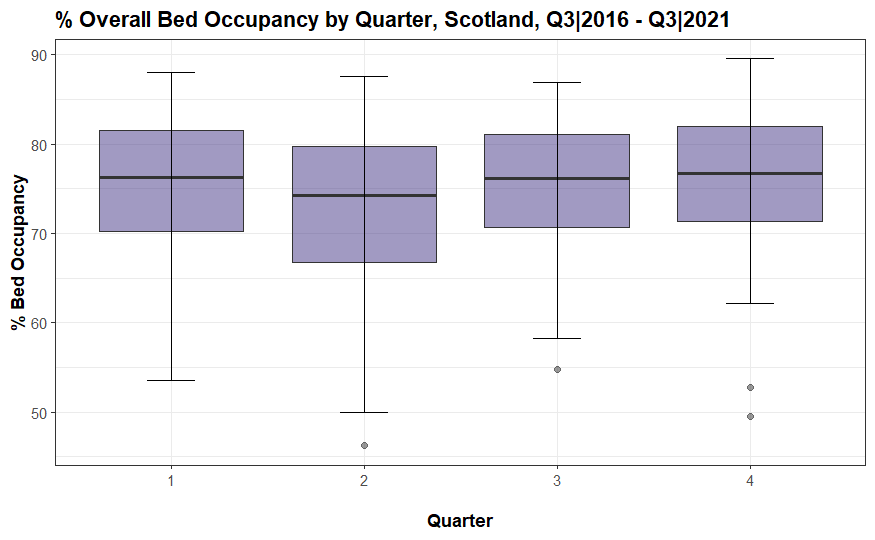

```r
beds_by_hb_trim %>%
  separate(quarter, into = c("year", "quarter"), sep = "Q") %>%
  ggplot() +
  aes(x = quarter, y = hb_mean_occupancy) +
  geom_boxplot(fill = "#433685", alpha = 0.5) +
  stat_boxplot(geom = "errorbar", width = 0.25) +
  theme_bw() +
  labs(title = "% Overall Bed Occupancy by Quarter, Scotland, Q3|2016 - Q3|2021",
       x = "\nQuarter",
       y = "% Bed Occupancy") +
  theme(title = element_text(face = "bold"))
```

```r
NA
```

## First Hypothesis Test;

## For data available in the years before the covid pandemic, is the average acute

## bed occupancy in winter (Q4 + Q1) significantly greater than in summer (Q2 + Q3)?

Focus on pre-covid timeline (2016 - 2019) to set a benchmark;

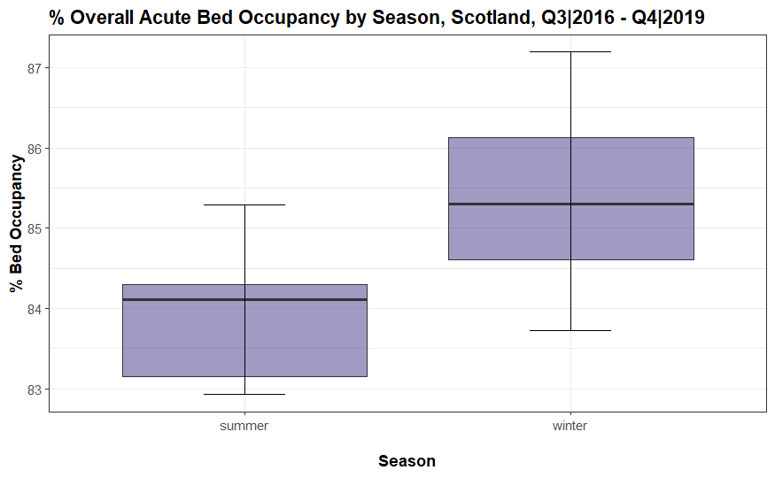

```r
seasonal_precovid_total_avg_acute_occupancy <- total_avg_acute_occupancy %>%
  separate(quarter, into = c("year", "quarter"), sep = "Q") %>%
  mutate(season = if_else(quarter == 1 | quarter == 4, "winter", "summer"),
         .after = "quarter") %>%
  filter(year <= 2019)

seasonal_precovid_total_avg_acute_occupancy %>%
  ggplot() +
  aes(x = season, y = mean_total_acute_occupancy) +
  geom_boxplot(fill = "#433685", alpha = 0.5) +
  stat_boxplot(geom = "errorbar", width = 0.25) +
  theme_bw() +
  labs(title = "% Overall Acute Bed Occupancy by Season, Scotland, Q3|2016 - Q4|2019",
       x = "\nSeason",
       y = "% Bed Occupancy") +
  theme(title = element_text(face = "bold"))
```

Set α = 0.05.

Null hypothesis H0: Mean acute bed occupancy between 2016 - 2019 is the same in the summer months as in the winter months;
$$H_0: μ_{winter2016 - 2019} − μ_{summer2016 - 2019} = 0$$

Alternative hypothesis H1: Mean acute bed occupancy between 2016 - 2019 is greater in winter than in summer;
$$H_1: μ_{winter2016 - 2019} − μ_{summer2016 - 2019} > 0$$

Generation of null distribution: under H0, where xs and ys are independent, it wouldn’t matter how you split the observations into group 1 or group 2, there wouldn’t be a statistically significant difference between the means or proportions of the 2 groups. So randomly shuffle (permute) the labels (the ys) of the observations to randomly assign the observations into groups 1 and 2. We then calculate the difference in sample means or proportions for the two groups. This is repeated many times (e.g. 10,000) to create the null distribution.

```r
observed_stat <- seasonal_precovid_total_avg_acute_occupancy %>%
  specify(mean_total_acute_occupancy ~ season) %>%
  calculate(stat = "diff in means", order = c("winter", "summer"))

observed_stat
```

```
Response: mean_total_acute_occupancy (numeric)
Explanatory: season (factor)
```

| stat |
| --- |
| 1.496003 |

Generate and visualise the null distribution with observed_stat overlaid;

```r
null_distribution <- seasonal_precovid_total_avg_acute_occupancy %>%
  specify(mean_total_acute_occupancy ~ season) %>%
  hypothesize(null = "independence") %>%
  generate(reps = 10000, type = "permute") %>%
  calculate(stat = "diff in means", order = c("winter", "summer"))
View(hospitals)
```

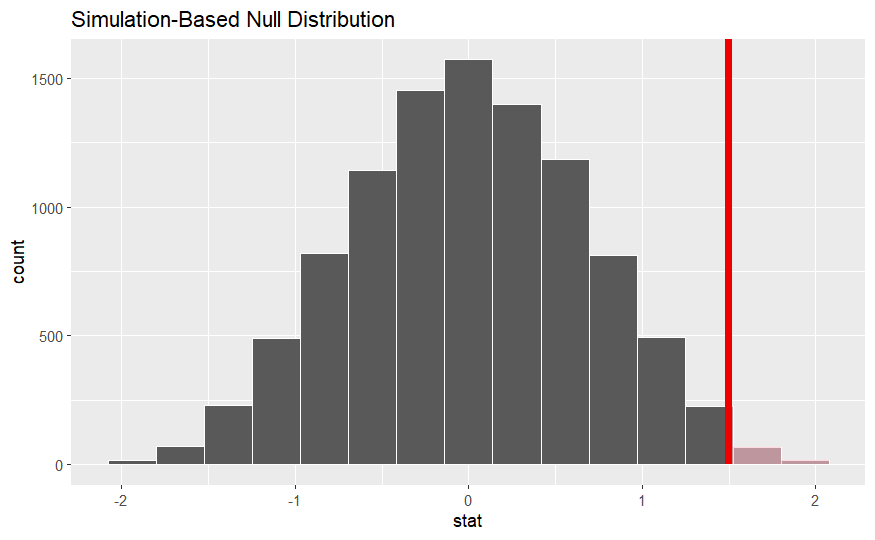

```r
null_distribution %>%
  visualise() +
  shade_p_value(obs_stat = observed_stat, direction = "right")
```

Calculate the p-value;

```r
p_value <- null_distribution %>%
  get_p_value(obs_stat = observed_stat, direction = "right")

p_value
```

| p_value |
| --- |
| 0.0108 |

## Conclusion of first hypothesis test;

The p-value for this test is below α = 0.05. In this case we reject H0 and conclude that there is enough evidence in our data to suggest that the average acute bed occupancy in winter is statistically significantly greater than in summer.

## Second Hypothesis Test;

## For data available in the years during the covid pandemic, is the average acute

## bed occupancy in winter (Q4 + Q1) significantly greater than in summer (Q2 + Q3)?

Focus on covid-affected timeline (2020 - 2021);

[output not shown]

It looks like there’s a really low value in the summer distribution; is this an outlier > 3σ from the mean? Check z-score;

| year | quarter | season | mean_total_acute_occupancy | z_occupancy |
| --- | --- | --- | --- | --- |
| 2020 | 2 | summer | 59.21024 | -1.44220118 |
| 2020 | 3 | summer | 73.62542 | 0.09773719 |
| 2021 | 2 | summer | 78.46093 | 0.61430322 |
| 2021 | 3 | summer | 79.54546 | 0.73016077 |

So within the context of 2020-2021 seasonal data there are no data points more than 3σ from the mean. The closest point to this is the data point for 2020 Q2, at -1.44σ.

Set α = 0.05.

Null hypothesis H0: Mean acute bed occupancy between 2020 - 2021 is the same in the summer months as in the winter months;
$$H_0: μ_{winter2020 - 2021} − μ_{summer2020 - 2021} = 0$$

Alternative hypothesis H1: Mean acute bed occupancy between 2020 - 2021 is greater in winter than in summer;
$$H_1: μ_{winter2020 - 2021} − μ_{summer2020 - 2021} > 0$$

Generation of null distribution: under H0, where xs and ys are independent, it wouldn’t matter how you split the observations into group 1 or group 2, there wouldn’t be a statistically significant difference between the means or proportions of the 2 groups. So randomly shuffle (permute) the labels (the ys) of the observations to randomly assign the observations into groups 1 and 2. We then calculate the difference in sample means or proportions for the two groups. This is repeated many times (e.g. 10,000) to create the null distribution.

```r
observed_stat <- seasonal_postcovid_total_avg_acute_occupancy %>%
  specify(mean_total_acute_occupancy ~ season) %>%
  calculate(stat = "diff in means", order = c("winter", "summer"))

observed_stat
```

```
Response: mean_total_acute_occupancy (numeric)
Explanatory: season (factor)
```

| stat |
| --- |
| 6.061127 |

Generate and visualise the null distribution with observed_stat overlaid;

```r
null_distribution <- seasonal_postcovid_total_avg_acute_occupancy %>%
  specify(mean_total_acute_occupancy ~ season) %>%
  hypothesize(null = "independence") %>%
  generate(reps = 10000, type = "permute") %>%
  calculate(stat = "diff in means", order = c("winter", "summer"))
```

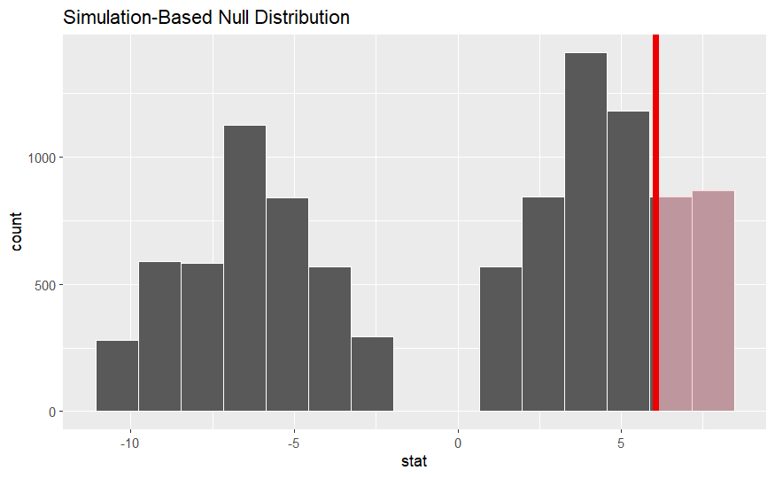

```r
null_distribution %>%
  visualise() +
  shade_p_value(obs_stat = observed_stat, direction = "right")
```

Calculate the p-value;

```r
p_value <- null_distribution %>%
  get_p_value(obs_stat = observed_stat, direction = "right")

p_value
```

| p_value |
| --- |
| 0.1713 |

## Third Hypothesis Test;

## For all data available in before and during the covid pandemic, is the average acute

## bed occupancy in winter (Q4 + Q1) significantly greater than in summer (Q2 + Q3)?

Use all data (2016 - 2021);

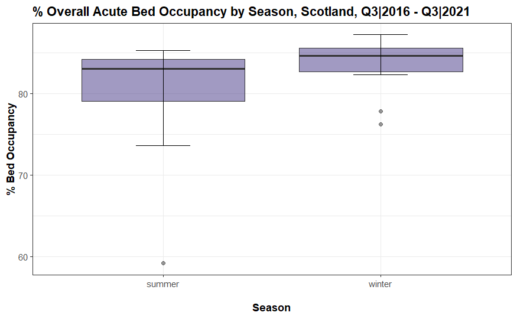

```r
seasonal_total_avg_acute_occupancy <- total_avg_acute_occupancy %>%
  separate(quarter, into = c("year", "quarter"), sep = "Q") %>%
  mutate(season = if_else(quarter == 1 | quarter == 4, "winter", "summer"),
         .after = "quarter")

seasonal_total_avg_acute_occupancy %>%
  ggplot() +
  aes(x = season, y = mean_total_acute_occupancy) +
  geom_boxplot(fill = "#433685", alpha = 0.5) +
  stat_boxplot(geom = "errorbar", width = 0.25) +
  theme_bw() +
  labs(title = "% Overall Acute Bed Occupancy by Season, Scotland, Q3|2016 - Q3|2021",
       x = "\nSeason",
       y = "% Bed Occupancy") +
  theme(title = element_text(face = "bold"))
```

Set α = 0.05.

Null hypothesis H0: Average acute bed occupancy between 2016 - 2021 is the same in the summer months as in the winter months;
$$H_0: μ_{winter2016 - 2021} − μ_{summer2016 - 2021} = 0$$

Alternative hypothesis H1: Average acute bed occupancy between 2016 - 2021 is greater in winter than in summer;
$$H_1: μ_{winter2016 - 2021} − μ_{summer2016 - 2021} > 0$$

Generation of null distribution: under H0, where xs and ys are independent, it wouldn’t matter how you split the observations into group 1 or group 2, there wouldn’t be a statistically significant difference between the means or proportions of the 2 groups. So randomly shuffle (permute) the labels (the ys) of the observations to randomly assign the observations into groups 1 and 2. We then calculate the difference in sample means or proportions for the two groups. This is repeated many times (e.g. 10,000) to create the null distribution.

```r
observed_stat <- seasonal_total_avg_acute_occupancy %>%
  specify(mean_total_acute_occupancy ~ season) %>%
  calculate(stat = "diff in means", order = c("winter", "summer"))

observed_stat
```

```
Response: mean_total_acute_occupancy (numeric)
Explanatory: season (factor)
```

| stat |
| --- |
| 3.576941 |

Generate and visualise the null distribution with observed_stat overlaid;

```r
null_distribution <- seasonal_total_avg_acute_occupancy %>%
  specify(mean_total_acute_occupancy ~ season) %>%
  hypothesize(null = "independence") %>%
  generate(reps = 10000, type = "permute") %>%
  calculate(stat = "diff in means", order = c("winter", "summer"))
```

[figure not shown]

Calculate the p-value;

```r
p_value <- null_distribution %>%
  get_p_value(obs_stat = observed_stat, direction = "right")

p_value
```

| p_value |
| --- |
| 0.0986 |

This is larger than our alpha level of 0.05 which means that we cannot reject H0. That means we cannot say from the evidence in this dataset that the difference in average bed occupancy across the whole dataset including pre- and post-covid onset is varying on a seasonal basis. This may change if we extended our timeline to include earlier data.

## Fourth Hypothesis Test;

## For data available in the years during the covid pandemic, is the average acute

## bed occupancy in winter (Q4 + Q1) significantly greater than in summer (Q2 + Q3),

## not including the initial outlier for 2020Q2?

Focus on covid-affected timeline (2020 - 2021);

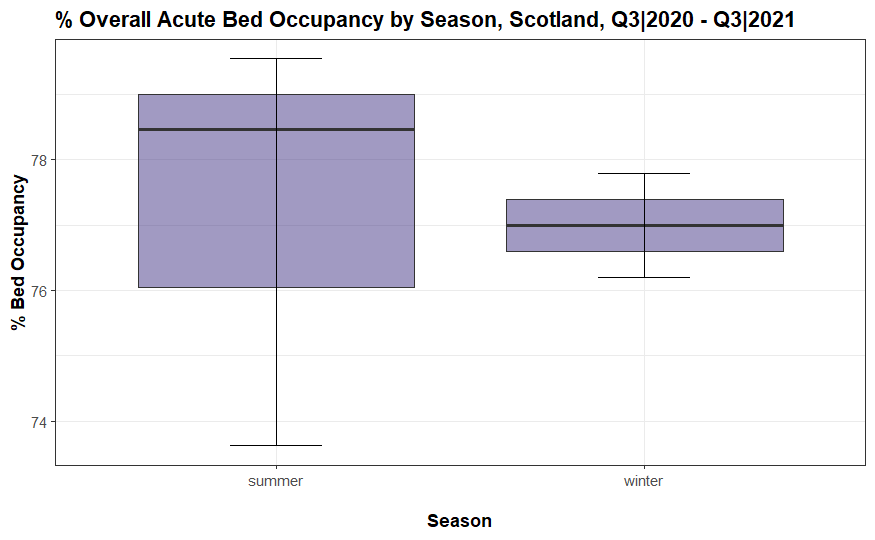

```r
seasonal_postcovid_total_avg_acute_occupancy <- total_avg_acute_occupancy %>%
  filter(quarter > "2020Q2") %>%
  separate(quarter, into = c("year", "quarter"), sep = "Q") %>%
  mutate(season = if_else(quarter == 1 | quarter == 4, "winter", "summer"),
         .after = "quarter")

seasonal_postcovid_total_avg_acute_occupancy %>%
  ggplot() +
  aes(x = season, y = mean_total_acute_occupancy) +
  geom_boxplot(fill = "#433685", alpha = 0.5) +
  stat_boxplot(geom = "errorbar", width = 0.25) +
  theme_bw() +
  labs(title = "% Overall Acute Bed Occupancy by Season, Scotland, Q3|2020 - Q3|2021",
       x = "\nSeason",
       y = "% Bed Occupancy") +
  theme(title = element_text(face = "bold"))
```

Set α = 0.05.

Null hypothesis H0: Mean acute bed occupancy between 2020 - 2021 is the same in the summer months as in the winter months;
$$H_0: μ_{winter2020 - 2021} − μ_{summer2020 - 2021} = 0$$

Alternative hypothesis H1: Mean acute bed occupancy between 2020 - 2021 is greater in winter than in summer;
$$H_1: μ_{winter2020 - 2021} − μ_{summer2020 - 2021} > 0$$

Generation of null distribution: under H0, where xs and ys are independent, it wouldn’t matter how you split the observations into group 1 or group 2, there wouldn’t be a statistically significant difference between the means or proportions of the 2 groups. So randomly shuffle (permute) the labels (the ys) of the observations to randomly assign the observations into groups 1 and 2. We then calculate the difference in sample means or proportions for the two groups. This is repeated many times (e.g. 10,000) to create the null distribution.

```r
observed_stat <- seasonal_postcovid_total_avg_acute_occupancy %>%
  specify(mean_total_acute_occupancy ~ season) %>%
  calculate(stat = "diff in means", order = c("winter", "summer"))

observed_stat
```

```
Response: mean_total_acute_occupancy (numeric)
Explanatory: season (factor)
```

| stat |
| --- |
| -0.2161897 |

Generate and visualise the null distribution with observed_stat overlaid;

```r
null_distribution <- seasonal_postcovid_total_avg_acute_occupancy %>%
  specify(mean_total_acute_occupancy ~ season) %>%
  hypothesize(null = "independence") %>%
  generate(reps = 100000, type = "permute") %>%
  calculate(stat = "diff in means", order = c("winter", "summer"))
```

[figure not shown]

Calculate the p-value;

```r
p_value <- null_distribution %>%
  get_p_value(obs_stat = observed_stat, direction = "right")

p_value
```

| p_value |
| --- |
| 0.60244 |